# Data Manipulation, Exploration and Visualization

## Preface

### R packages

In this practical, a number of R packages are used. The packages used (with versions that were used to generate the solutions) are:

- R version 3.6.2 (2019-12-12)
- `survival` (version: 3.1.8)
- `memisc` (version: 0.99.22)
- `ggplot2` (version: 3.2.1)

### Dataset

For this practical, we will use the **heart** and **retinopathy** data sets from the `survival` package. More details about the data sets can be found in:

https://stat.ethz.ch/R-manual/R-devel/library/survival/html/heart.html

https://stat.ethz.ch/R-manual/R-devel/library/survival/html/retinopathy.html

## Data Manipulation, Exploration and Visualization

Before starting with any statistical analysis it is important to transform and explore your data set.

### Data Manipulation

#### Task 1

- As mentioned in the manual of the **heart** data set, `age` is equal to `age` - 48. Let’s bring `age` back to the normal scale. Do not overwrite the variable `age`, but create a new variable with the name `age_orig`.
- Convert the variable `surgery` into a factor with levels 0: `no` and 1: `yes`.

Use the function factor(…) to convert a numerical variable to a factor.

#### Solution 1

```r
heart$age_orig <- heart$age + 48
heart$surgery <- factor(heart$surgery, levels = c(0, 1), labels = c("no", "yes"))
```

#### Task 2

Categorize the variable `age` from the **retinopathy** data set as `young`: [minimum `age` until mean `age`) and `old`: [mean `age` until maximum `age`). Give this variable the name `ageCat`. Print the first 6 rows of the data set **retinopathy**.

To dichotomize a numerical variable use the function as.numeric(…). Use the function factor(…) to convert a variable into a factor.

#### Solution 2

```r
retinopathy$ageCat <- as.numeric(retinopathy$age >= mean(retinopathy$age))
retinopathy$ageCat <- factor(retinopathy$ageCat, levels = c(0, 1), labels = c("young", "old"))
head(retinopathy)
```

|  | id | laser | eye | age | type | trt | futime | status | risk | ageCat |
| --- | --- | --- | --- | --- | --- | --- | --- | --- | --- | --- |
| 1 | 5 | argon | left | 28 | adult | 1 | 46.23 | 0 | 9 | old |
| 2 | 5 | argon | left | 28 | adult | 0 | 46.23 | 0 | 9 | old |
| 3 | 14 | argon | right | 12 | juvenile | 1 | 42.50 | 0 | 8 | young |
| 4 | 14 | argon | right | 12 | juvenile | 0 | 31.30 | 1 | 6 | young |
| 5 | 16 | xenon | right | 9 | juvenile | 1 | 42.27 | 0 | 11 | young |
| 6 | 16 | xenon | right | 9 | juvenile | 0 | 42.27 | 0 | 11 | young |

#### Task 3

Use the function cut(…, right = FALSE) to convert a continuous variable to a categorical variable. If you need help check ?cut. Use the function factor(…) to convert a variable into a factor.

#### Solution 3

```r
retinopathy$futimeCat <- cut(retinopathy$futime, c(min(retinopathy$futime), 25, 45, max(retinopathy$futime)), right = FALSE)
retinopathy$futimeCat <- factor(retinopathy$futimeCat, levels = c("[0.3,25)", "[25,45)", "[45,75)"), labels = c("short", "medium", "long"))
head(retinopathy)
```

|  | id | laser | eye | age | type | trt | futime | status | risk | ageCat | futimeCat |
| --- | --- | --- | --- | --- | --- | --- | --- | --- | --- | --- | --- |
| 1 | 5 | argon | left | 28 | adult | 1 | 46.23 | 0 | 9 | old | long |
| 2 | 5 | argon | left | 28 | adult | 0 | 46.23 | 0 | 9 | old | long |
| 3 | 14 | argon | right | 12 | juvenile | 1 | 42.50 | 0 | 8 | young | medium |
| 4 | 14 | argon | right | 12 | juvenile | 0 | 31.30 | 1 | 6 | young | medium |
| 5 | 16 | xenon | right | 9 | juvenile | 1 | 42.27 | 0 | 11 | young | medium |
| 6 | 16 | xenon | right | 9 | juvenile | 0 | 42.27 | 0 | 11 | young | medium |

#### Task 4

Create 2 vectors of size 50 as follows:

- `Sex`: takes 2 values 0 and 1.
- `Age`: takes values from 20 till 80.
- Convert the `Sex` variable into a factor with levels 0: `female` and 1: `male`.
- Define the new variable `AgeCat` as dichotomous with `Age` <= 50 to be 0 and 1 otherwise.
- Convert the `AgeCat` variable into a factor with levels 0: `young` and 1: `old`.
- Overwrite the `Age` variable by $\frac{Age-mean(Age)}{sd(Age)}$.

To sample a numerical and categorical variable use the function sample(…). To convert a numerical variable to a categorical use the function factor(…). To dichotomize a numerical variable use the function as.numeric(…).

#### Solution 4

```r
Sex <- sample(0:1, 50, replace = T)
Age <- sample(20:80, 50, replace = T)
Sex <- factor(Sex, levels = c(0:1), labels = c("female", "male"))
AgeCat <- as.numeric(Age > 50)
AgeCat <- factor(AgeCat, levels = c(0:1), labels = c("young", "old"))
Age <- (Age - mean(Age))/sd(Age)
```

#### Task 5

Create a data frame with the name `DF` as follows:

- Include the following vectors: `Sex`, `Age`, `AgeCat` form the previous Task.
- Use the names: `Gender`, `StandardizedAge`, `DichotomousAge`.

#### Solution 5

```r
DF <- data.frame(Sex, Age, AgeCat)
DF <- data.frame("Gender" = Sex, "StandardizedAge" = Age, "DichotomousAge" = AgeCat)
```

#### Task 6

Create 2 vectors of size 150 as follows:

- `Treatment`: takes 2 values 1 and 2.
- `Weight`: takes values from 50 till 100.
- Convert the `Treatment` variable into a factor with levels 1: `no` and 2: `yes`.
- Overwrite the `Weight` variable by `Weight` * 1000.
- Create a data frame including `Treatment` and `Weight`.

To sample a numerical and categorical variable use the function sample(…). To convert a numerical variable to a categorical use the function factor(…).

#### Solution 6

```r
Treatment <- sample(1:2, 150, replace = T)
Weight <- sample(50:100, 150, replace = T)
Treatment <- factor(Treatment, levels = c(1:2), labels = c("no", "yes"))
Weight <- Weight * 1000
data.frame(Treatment, Weight)
```

| Treatment | Weight |
| --- | --- |
| yes | 95000 |
| yes | 100000 |
| yes | 67000 |
| yes | 66000 |
| no | 100000 |
| no | 60000 |
| no | 70000 |
| yes | 70000 |
| no | 86000 |
| no | 98000 |

[output cut: 140 more lines]

#### Task 7

Create a list called `my_list` with the following:

- `let`: `a` to `i`.
- `sex`: factor taking the values `males` and `females` and length 50.
- `mat`: matrix

  | 1 | 2 |
  | --- | --- |
  | 3 | 4 |

To obtain letters use the function letters(…). To sample a numerical and categorical variable use the function sample(…). To convert a numerical variable to a categorical use the function factor(…).

#### Solution 7

```r
let <- letters[1:9]
sex <- sample(1:2, 50, replace = TRUE)
sex <- factor(sex, levels = 1:2, labels = c("males", "females"))
mat <- matrix(1:4 ,2, 2, byrow = TRUE)
my_list <- list(let = let, sex = sex, mat = mat)
```

### Data Exploration

Let’s obtain some descriptive statistics.

#### Task 1

Obtain the mean and standard deviation for the variable `age` using the **heart** data set.

Use the functions mean(…) and sd(…).

#### Solution 1

```r
mean(heart$age)
```

```
## [1] -2.484027
```

```r
sd(heart$age)
```

```
## [1] 9.419999
```

#### Task 2

Using the **retinopathy** data set:

- Obtain the median and interquartile range for `age`.
- Obtain the percentage per `type`.
- Check whether there are missing in the variable `age`.

Use the functions median(…) and IQR(…) to obtain the median and the interquartile range. Load the package memisc and use the function percent(…) in order to obtain the percentages. To check whether there are missing values use the functions sum(is.na(…)).

#### Solution 2

```r
median(retinopathy$age)
```

```
## [1] 16
```

```r
IQR(retinopathy$age)
```

```
## [1] 20
```

```r
library(memisc)
percent(retinopathy$type)
```

```
##  juvenile     adult         N
##  57.86802  42.13198 394.00000
```

```r
sum(is.na(retinopathy$age)) # any(is.na(retinopathy$age))
```

```
## [1] 0
```

#### Task 3

Using the data frame `DF` from the exercise before (Task 5):

- Calculate the mean of the variable `StandardizedAge`.
- Calculate the standard deviation of the variable `StandardizedAge`.
- Calculate the frequencies of the variable `Gender`.
- Calculate the frequencies of the variable `DichotomousAge`.
- Calculate the frequencies of both variables `Gender` and `DichotomousAge` (crosstab table).
- What are the dimensions of the data.frame?

To calculate the frequencies, use the functions length() or table(). To obtain the dimensions use the function dim(…).

#### Solution 3

```r
mean(DF$StandardizedAge)
```

```
## [1] -5.911721e-17
```

```r
sd(DF$StandardizedAge)
```

```
## [1] 1
```

```r
length(DF$Gender[DF$Gender == "female"])
```

```
## [1] 23
```

```r
length(DF$Gender[DF$Gender == "male"])
```

```
## [1] 27
```

```r
table(DF$Gender)
```

```
##
## female   male
##     23     27
```

```r
table(DF$Gender, DF$DichotomousAge)
```

```
##
##          young old
##   female    11  12
##   male       8  19
```

```r
dim(DF)
```

```
## [1] 50  3
```

### Data Visualization

Let’s visualize the data.

#### Task 1

Using the **heart** data set:

- Create a scatterplot with the variables `age` and `year`
- Change the labels of the axis. In particular, give the name `Age` for the x-axis and `Year of acceptance` for the y-axis.
- Give a different color to the patients that had a transplant.
- Add a legend.

Use the function plot(…, xlab, ylab, col). Use the function legend(…) to add a legend to the plot.

#### Solution 1

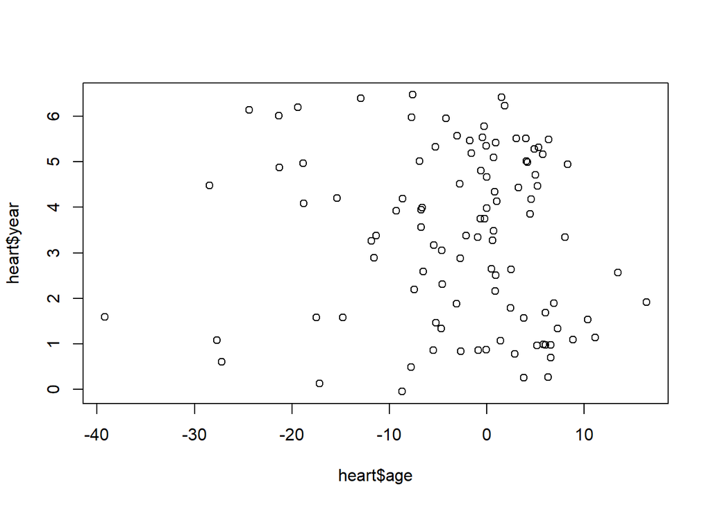

```r
plot(heart$age, heart$year)
```

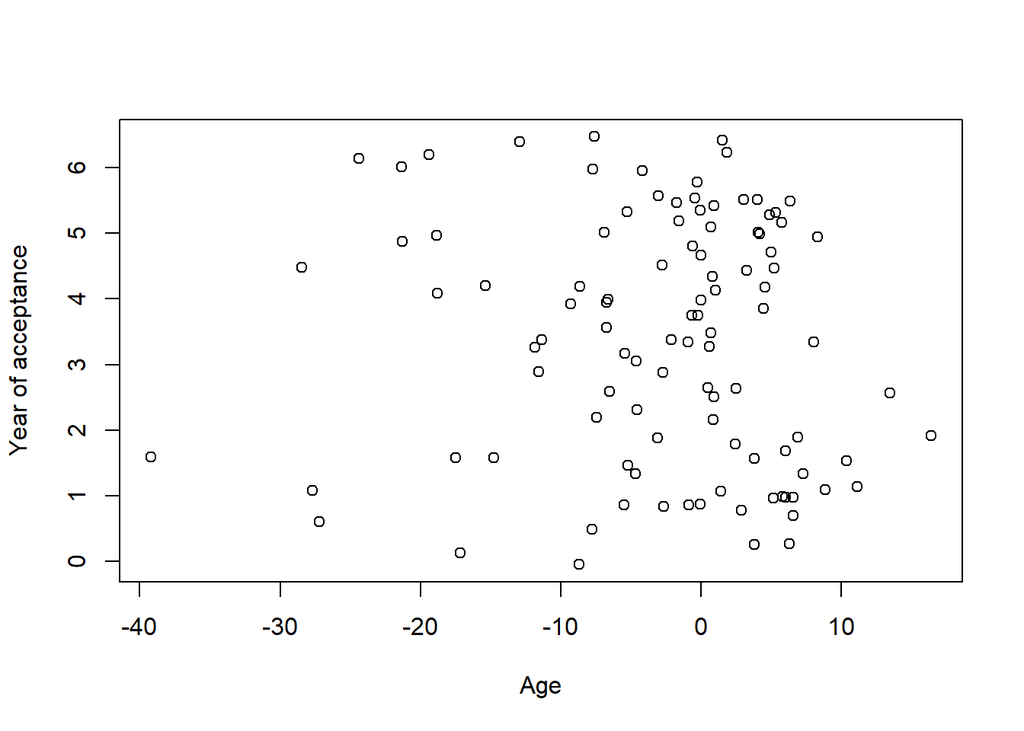

```r
plot(heart$age, heart$year, xlab = "Age", ylab = "Year of acceptance")
```

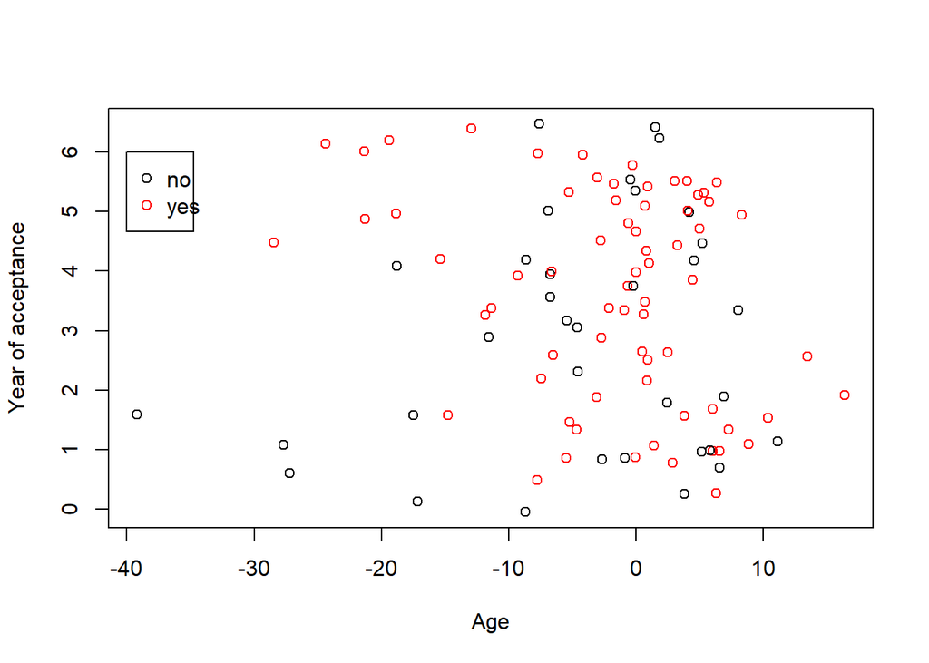

```r
plot(heart$age, heart$year, xlab = "Age", ylab = "Year of acceptance", col = heart$transplant)
legend(-40, 6, c("no", "yes"), col = c("black", "red"), pch = 1)
```

#### Task 2

Using the **retinopathy** data set:

- Create a boxplot of `age` per `status`.
- Change the colour to blue and green respectively.

Use the function boxplot(…).

#### Solution 2

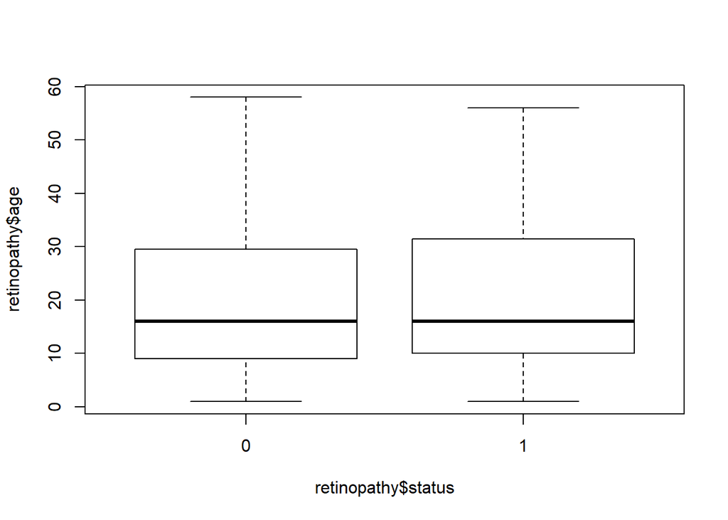

```r
boxplot(retinopathy$age ~ retinopathy$status)
```

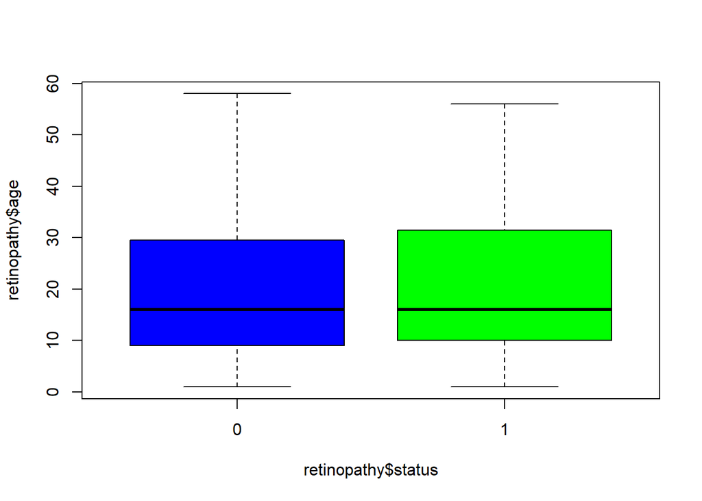

```r
boxplot(retinopathy$age ~ retinopathy$status, col = c("blue", "green"))
```

#### Task 3

Using the **retinopathy** data set:

- Create a smooth plot of `age` with `risk`.
- Create a density plot of `age` per `type` group.

Use the ggplot2 package and the functions: geom_smooth(…) and geom_density(…).

#### Solution 3

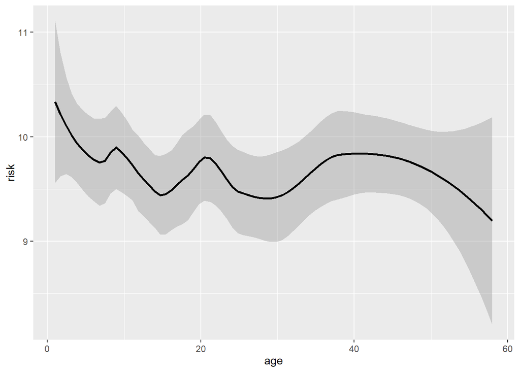

```r
library(ggplot2)
ggplot(retinopathy, aes(age, risk)) +
geom_smooth(colour='black', span = 0.4)
```

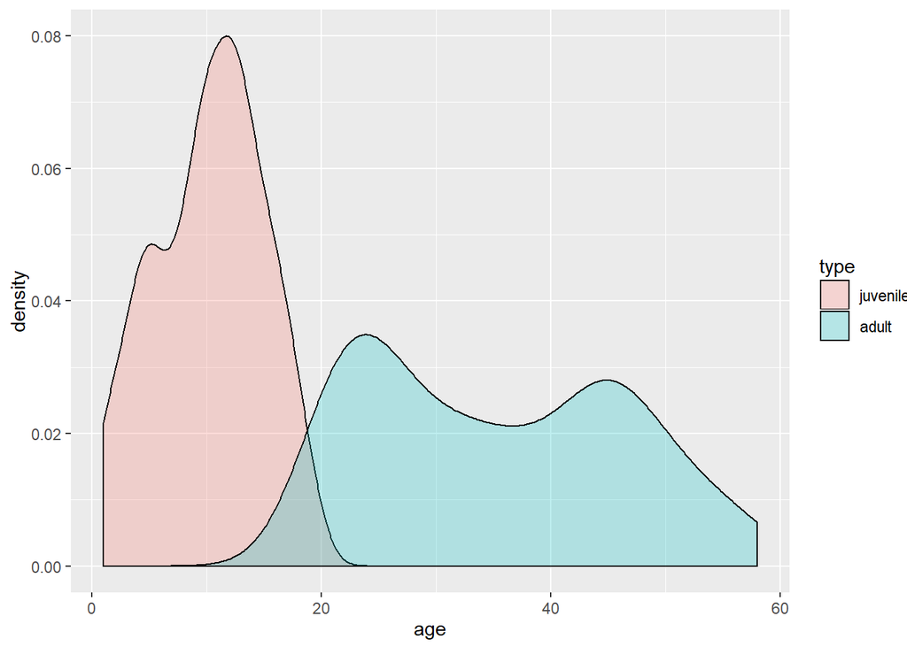

```r
ggplot(retinopathy, aes(age, fill = type)) +
geom_density(alpha = 0.25)
```

© Eleni-Rosalina Andrinopoulou